# Linear Regression (Ordinary Least Squares)

- https://scikit-learn.org/stable/modules/generated/sklearn.linear_model.LinearRegression.
- Today, we will cover...
  - How to fit linear regression model
  - Practices on two different problems/datasets
    - 1. a toy example "wave" dataset
    - 1. "Boston Housing Price" dataset
- If you are interested in, you can also read "4 ** " section to see the case that n_samples < n_features (sigular covariance matrix)

```python
import numpy as np
import pandas as pd
import matplotlib.pyplot as plt
```

## 1. Linear Regression on "wave" dataset

### (1) Prepare an example data

- "wave" dataset that the textbook provides

```python
import mglearn
X, y = mglearn.datasets.make_wave(n_samples=60)
```

```python
print(X.shape, y.shape)
```

```
(60, 1) (60,)
```

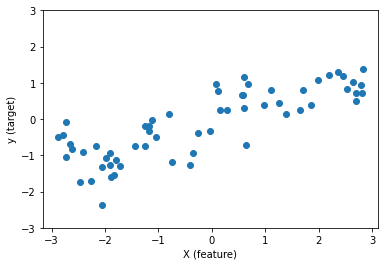

```python
plt.plot(X, y, 'o')
plt.ylim(-3, 3)
plt.xlabel("X (feature)")
plt.ylabel("y (target)")
```

### (2) Split the data into training and test sets

```python
from sklearn.model_selection import train_test_split
X_train, X_test, y_train, y_test = train_test_split(X, y, random_state=42)
```

### (3) Define and Train a linear regression model

```python
from sklearn.linear_model import LinearRegression
reg = LinearRegression()
reg.fit(X_train, y_train)
```

```
LinearRegression()
```

```python
print("the resulting coeffients of the linear regression (w1):", reg.coef_)
print("the resulting intercept of the linear regression (w0):", reg.intercept_)
```

```
the resulting coeffients of the linear regression (w1): [0.39390555]
the resulting intercept of the linear regression (w0): -0.031804343026759746
```

```
w[0]: 0.393906  b: -0.031804
```

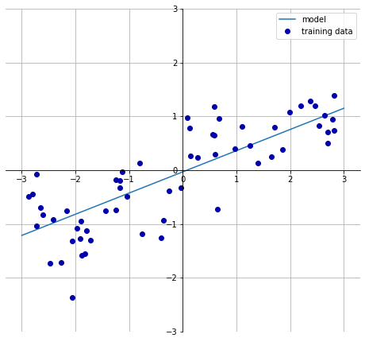

```python
mglearn.plots.plot_linear_regression_wave()
```

### (4) Test and Evaluate the model

```python
y_test_hat = reg.predict(X_test)
print(y_test)
print(y_test_hat)
```

```
[-1.18073311 -2.37364735 -0.19612826  0.40012342 -1.30838148  0.65213403
  0.70945882  0.23938228  1.0738403  -1.54664568 -0.02565504  0.73141352
 -1.0767626   1.17396178  1.01581268]
[-0.3283204  -0.84483835 -0.49358667  0.35230624 -0.71167167  0.19957573
  1.02910669  0.07859229  0.75390167 -0.75032857 -0.47681266  1.07802761
 -0.8104986   0.2013684   1.00692209]
```

```python
from sklearn.metrics import mean_squared_error, mean_absolute_error, r2_score
print('MSE : %.4f' % mean_squared_error(y_test, y_test_hat))
print('RMSE : %.4f' % mean_squared_error(y_test, y_test_hat)**0.5)
print('MAE : %.4f' % mean_absolute_error(y_test, y_test_hat))
print('R-square : %.4f' % r2_score(y_test, y_test_hat))
```

```
MSE : 0.3947
RMSE : 0.6283
MAE : 0.4945
R-square : 0.6593
```

## 2. Linear Regression on Boston Housing Price Data

### (1) Prepare the dataset

```python
from sklearn.datasets import load_boston
boston = load_boston()
```

[output not shown]

```python
import warnings
warnings.filterwarnings(action='ignore')
```

```python
boston.keys()
```

```
dict_keys(['data', 'target', 'feature_names', 'DESCR', 'filename', 'data_module'])
```

```python
boston.feature_names
```

```
array(['CRIM', 'ZN', 'INDUS', 'CHAS', 'NOX', 'RM', 'AGE', 'DIS', 'RAD',
       'TAX', 'PTRATIO', 'B', 'LSTAT'], dtype='<U7')
```

```python
X = boston.data
y = boston.target
```

```python
print(X.shape, y.shape)
```

```
(506, 13) (506,)
```

### (2) Split the data into training and test sets

```python
X_train, X_test, y_train, y_test = train_test_split(X, y, random_state=42)
```

### (3) Define and Train a linear regression model

```python
from sklearn.linear_model import LinearRegression
reg = LinearRegression()
reg.fit(X_train, y_train)
```

```
LinearRegression()
```

```python
print("the resulting coeffients of the linear regression (w1): \n", reg.coef_)
print("the resulting intercept of the linear regression (w0):", reg.intercept_)
```

```
the resulting coeffients of the linear regression (w1):
 [-1.28322638e-01  2.95517751e-02  4.88590934e-02  2.77350326e+00
 -1.62388292e+01  4.36875476e+00 -9.24808158e-03 -1.40086668e+00
  2.57761243e-01 -9.95694820e-03 -9.23122944e-01  1.31854199e-02
 -5.17639519e-01]
the resulting intercept of the linear regression (w0): 29.836420163838618
```

### (4) Test and Evaluate the model

```python
y_train_hat = reg.predict(X_train)
y_test_hat = reg.predict(X_test)

print('train RMSE : %.4f' % mean_squared_error(y_train, y_train_hat)**0.5)
print('train MAE : %.4f' % mean_absolute_error(y_train, y_train_hat))
print('train R-square : %.4f' % r2_score(y_train, y_train_hat))

print('test RMSE : %.4f' % mean_squared_error(y_test, y_test_hat)**0.5)
print('test MAE : %.4f' % mean_absolute_error(y_test, y_test_hat))
print('test R-square : %.4f' % r2_score(y_test, y_test_hat))
```

```
train RMSE : 4.7265
train MAE : 3.3663
train R-square : 0.7481
test RMSE : 4.7009
test MAE : 3.0609
test R-square : 0.6844
```

## 2-1. Check the coefficients

- here, I'll test if the coefficients agree the equation that we obtained in the lecture : $(X^TX)^{-1}X^Ty$

```python
X_new = np.ones((X_train.shape[0],X_train.shape[1]+1))
X_new[:,1:] = X_train
print(X_new.shape)
```

```
(379, 14)
```

```python
inv = np.linalg.inv(np.dot(X_new.transpose(), X_new))
coeff = inv.dot(X_new.transpose()).dot(y_train)
print("coefficients (w1,w2,...) are : \n", coeff[1:])
print("intercept (w0) is : ", coeff[0])
```

```
coefficients (w1,w2,...) are :
 [-1.28322638e-01  2.95517751e-02  4.88590934e-02  2.77350326e+00
 -1.62388292e+01  4.36875476e+00 -9.24808158e-03 -1.40086668e+00
  2.57761243e-01 -9.95694820e-03 -9.23122944e-01  1.31854199e-02
 -5.17639519e-01]
intercept (w0) is :  29.83642016382942
```

## 3. Regression for the extened Boston Housing Price dataset

- when the number of (useful) features increses, the model performance will be ...

```python
X, y = mglearn.datasets.load_extended_boston()
print(X.shape, y.shape)
```

```
(506, 104) (506,)
```

```python
X_train, X_test, y_train, y_test = train_test_split(X, y, random_state=42)

from sklearn.linear_model import LinearRegression
reg = LinearRegression()
reg.fit(X_train, y_train)

y_train_hat = reg.predict(X_train)
y_test_hat = reg.predict(X_test)

print('train RMSE : %.4f' % mean_squared_error(y_train, y_train_hat)**0.5)
print('train MAE : %.4f' % mean_absolute_error(y_train, y_train_hat))
print('train R-square : %.4f' % r2_score(y_train, y_train_hat))

print('test RMSE : %.4f' % mean_squared_error(y_test, y_test_hat)**0.5)
print('test MAE : %.4f' % mean_absolute_error(y_test, y_test_hat))
print('test R-square : %.4f' % r2_score(y_test, y_test_hat))
```

```
train RMSE : 2.2119
train MAE : 1.7068
train R-square : 0.9448
test RMSE : 3.9620
test MAE : 2.5832
test R-square : 0.7758
```

## 4. ** Check the case that n < p

```python
X, y = mglearn.datasets.load_extended_boston()
print(X.shape, y.shape)
```

```
(506, 104) (506,)
```

```python
n = 10 # number of samples
X = X[:n,:]
y = y[:n]
print(X.shape, y.shape)
```

```
(10, 104) (10,)
```

```python
X_new = np.ones((X.shape[0],X.shape[1]+1))
X_new[:,1:] = X
```

```python
print(X_new.transpose().shape, X_new.shape)
```

```
(105, 10) (10, 105)
```

```python
np.linalg.inv(np.dot(X_new.transpose(), X_new))
```

```
---------------------------------------------------------------------------
LinAlgError                               Traceback (most recent call last)
/tmp/ipykernel_55815/1816270344.py in <module>
----> 1 np.linalg.inv(np.dot(X_new.transpose(), X_new))

<__array_function__ internals> in inv(*args, **kwargs)

~/anaconda3/envs/tensorflow/lib/python3.7/site-packages/numpy/linalg/linalg.py in inv(a)
    543     signature = 'D->D' if isComplexType(t) else 'd->d'
    544     extobj = get_linalg_error_extobj(_raise_linalgerror_singular)
--> 545     ainv = _umath_linalg.inv(a, signature=signature, extobj=extobj)
    546     return wrap(ainv.astype(result_t, copy=False))
    547

~/anaconda3/envs/tensorflow/lib/python3.7/site-packages/numpy/linalg/linalg.py in _raise_linalgerror_singular(err, flag)
     86
     87 def _raise_linalgerror_singular(err, flag):
---> 88     raise LinAlgError("Singular matrix")
     89
     90 def _raise_linalgerror_nonposdef(err, flag):

LinAlgError: Singular matrix
```

$\rightarrow$ which means $X^TX$ does not have inverse

```python
X_train, X_test, y_train, y_test = train_test_split(X, y, random_state=42)

from sklearn.linear_model import LinearRegression
reg = LinearRegression()
reg.fit(X_train, y_train)

y_train_hat = reg.predict(X_train)
y_test_hat = reg.predict(X_test)

print('train RMSE : %.4f' % mean_squared_error(y_train, y_train_hat)**0.5)
print('train MAE : %.4f' % mean_absolute_error(y_train, y_train_hat))
print('train R-square : %.4f' % r2_score(y_train, y_train_hat))

print('test RMSE : %.4f' % mean_squared_error(y_test, y_test_hat)**0.5)
print('test MAE : %.4f' % mean_absolute_error(y_test, y_test_hat))
print('test R-square : %.4f' % r2_score(y_test, y_test_hat))
```

```
train RMSE : 0.0000
train MAE : 0.0000
train R-square : 1.0000
test RMSE : 11.0620
test MAE : 9.8998
test R-square : -3.8891
```

$\rightarrow$ But, it works. Why?

- https://scikit-learn.org/stable/modules/linear_model.html

  > The coefficient estimates for Ordinary Least Squares rely on the independence of the features. When features are correlated and the columns of the design matrix have an approximately linear dependence, the design matrix $X$ becomes close to singular and as a result, the least-squares estimate becomes highly sensitive to random errors in the observed target, producing a large variance. This situation of multicollinearity can arise, for example, when data are collected without an experimental design.
- https://stackoverflow.com/questions/23714519/how-does-sklearn-do-linear-regression-when-p-n

  > When the linear system is underdetermined, then the sklearn.linear_model.LinearRegression finds the minimum L2 norm solution, i.e. $ \text{argmin}_w ||w|| \text{ s.t } Xw = y$
- https://stackoverflow.com/questions/65844656/results-of-sklearn-statsmodels-ordinary-least-squares-under-singular-covariance

  > The parameters estimated by Moore-Penrose inverse can be interpreted as symmetrically penalized or regularized estimates. The Moore-Penrose solution also obtains when we have Ridge Regression and the penalization weight goes to zero.

  > A software package has essentially 3 options to handle singular cases :
  > 1. raise an exception and refuse to compute anything
  > 2. drop some variables, question is which variables to drop
  > 3. switch to penalized solution including generalized inverse

#### Copyright 2022. Sujee Lee. All rights reserved.